# Vignette_1: Data Introduction with a mouse study: OGD_WT vs NORMOXIA_WT

# StellarPath

Welcome to the first vignette of our software StellarPath. This vignette focuses on explaining the main operations and the data produced by StellarPath.

## Brief introduction

StellarPath classifies two patients’/samples’ classes and works with both dense and sparse (e.g., somatic mutation) omics. It finds significantly deregulated and stable molecules together with their enriched pathways. It determines how much each pair of patients is similar by comparing the values of the molecules belonging to a specific pathway. It uses the pathway-specific similarities to build a patient similarity network (PSN). Only the PSNs, which show that one class is cohesive while the opposite one is not, are kept. StellarPath receives an unknown patient, adds it to a significant PSN and predicts its class with a graph convolutional network. The latter step is repeated with all PSNs and the final prediction is made by consensus/major voting. The unknown patient can be a testing patient of a cross-validation or can be a real unknown patient coming from a new dataset that is indipendent from the one used for training the model. This vignette will focus on StellarPath’s workflow based on cross-validation.

StellarPath provides multiple output data:

1. Normalized sequencing profiles ready for further analysis
2. Markers: significant molecules, pathways and PSNs able to predict a patient’s class
3. Novel information: the markers are analysed during the workflow and many statistics are provided to enable the user to understand which is the very best one
4. Class Signature PSNs representing a class being more cohesive and strong that the opposite one in term of a pathway specific regulation
5. Patient’s centralities: each patient is assigned to a pathway specific score that defines how much is similar to the member of its class and dissimilar to the non-members. Such score for each pathway/PSN allows to stratify a class of patients in subclasses.

## Case study

For this vignette, StellarPath is applied on a simple experimental study:

- We have: Oxygen-Glucose deprived mouse samples and Normoxia samples.
- We have: bulk RNA sequencing and small RNA sequencing for all the samples in study
- We want: deregulated pathways and molecules due to the deprivation of Oxygen and Glucose in mouse.
- We want: significant pathways and molecules being predictive of the samples’ classes
- We want: information to further prioritize and investigate pathways and molecules

# Enviroment set up

Let us clean the R enviroment, set the working directory, load the software package, set the random seed generator for reproducing always the same results and define the number of cores available in the computer to run the operations.

Be careful: set up the number of cores based on your resources, if you are not secure how to, then just set equal to 2

```r
#Clean workspace and memory ----
rm(list=ls())
gc()
```

```
#>          used (Mb) gc trigger (Mb) max used (Mb)
#> Ncells 510359 27.3    1125377 60.2   665582 35.6
#> Vcells 936764  7.2    8388608 64.0  1819332 13.9
```

```r
#Set working directory ----
gps0=getwd()
gps0=paste(gps0,"/%s",sep="")
rootDir=gps0
setwd(gsub("%s","",rootDir))

#Load libraries ----
library("StellarPath")
SP_initialize()
```

```
#> Bioconductor version '3.14' is out-of-date; the current release version '3.17'
#>   is available with R version '4.3'; see https://bioconductor.org/install
#>
#> This is StellarPath (version 1.9.0) .
#> StellarPath is new and still rapidly improving.
#>
#> Newer versions will improve functions and increase the omics which the software can process.
#>
#> Please send us feedback based on your experience.
```

```r
library("qs")
#Set variables ----
#Input
#Set the number of cores available in the system
n_cores=15
#output
#Set the output file where all the data and results will be stored in the end
out_res_path="classif_OGD.qs"
```

# Data set up

StellarPath is a binary classifier and works with one or multiple omics from high-throughput sequencing describing the two patient classes in comparison.

```r
#Load and set up the example data ----
data("ogd_l")

#Set name of the project, the specie id of the samples, the name of the classes to compare (case vs control)
name_dataset="OGD"
tax_id=10090
groups=c("OGD_WT","N_WT")

#Dataframe about samples' ids and classes
ogd_l$info
```

```
#>       ID_run  group
#> 3  OGD_WT_R1 OGD_WT
#> 7  OGD_WT_R2 OGD_WT
#> 31 OGD_WT_R3 OGD_WT
#> 35 OGD_WT_R4 OGD_WT
#> 39 OGD_WT_R5 OGD_WT
#> 1    N_WT_R1   N_WT
#> 5    N_WT_R2   N_WT
#> 29   N_WT_R3   N_WT
#> 33   N_WT_R4   N_WT
#> 37   N_WT_R5   N_WT
```

```r
#bulkRNAseq expression matrix
see(ogd_l$mRNA)
```

```
#>       OGD_WT_R1 OGD_WT_R2 OGD_WT_R3 OGD_WT_R4 OGD_WT_R5
#> Gnai3      1687      1850      1410       946       913
#> Pbsn          0         0         0         0         0
#> Cdc45       122        90        87        47        62
#> H19          19        15        19        19        18
#> Scml2        67        34        49        41        61
```

```r
#smallRNAseq expression matrix
see(ogd_l$miRNA)
```

```
#>                  OGD_WT_R1  OGD_WT_R2  OGD_WT_R3   OGD_WT_R4  OGD_WT_R5
#> mmu-let-7a-1-3p  387.52308  303.31391  270.12073  276.747485  281.58843
#> mmu-let-7a-5p   9226.34220 8606.88359 8128.25549 7783.001516 8613.29325
#> mmu-let-7b-3p     34.15708   32.54096   26.33252   18.078981   33.62999
#> mmu-let-7b-5p   5770.33419 5491.78952 6138.87579 5335.385565 6620.59079
#> mmu-let-7c-1-3p   19.65875   15.26613   11.89211    6.953454   10.54074
```

# Running Time and RAM Memory

StellarPath’s package includes functions to monitor the running time and the RAM usage of the classification

```r
#Start monitor RAM memory
log_path=start_monitor_ram(name_dataset)
```

```
#> Starting to monitor the RAM usage
```

```r
#Start monitor running time
startTime=Sys.time()
```

# Input data check up and preparation

We provide to StellarPath the info dataframe, the name of the classes to compare and the sequencing raw count matrices. StellarPath analyses omics from their normalization to integration in pathways without the need of a pre-processing.

```r
#Check input data and prepare object for downstream workflow
data_l=prepare_data(info = ogd_l$info,
                    groups_name = c("OGD_WT","N_WT"),
                    gex = ogd_l$mRNA,
                    miRNA = ogd_l$miRNA,
                    tax_id = tax_id,
                    n_cores = n_cores)
```

```
#> Checking input omics/raw count matrices
#> >gene expression data (genes per samples) found
#> >miRNA data (miRNA per samples) found
#> Checking input info
#> >dataframe format
#> >two columns
#> >does NOT contain NA values
#> >groups in comparison are two
#> >second column of info contains only labels which belong to the user defined group's names
#> Checking same sample's IDs between info first column and omics column names
#> >same order of existing samples between info dataframe and omics data
#> Checking format of input omics
#> >omics are in the same format
#> >omics are matrices
#> Ordering samples based on groups
#> >The comparison and classification is with:
#> >>first group : OGD_WT of samples: 5
#> >>second group : N_WT of samples: 5
#> Simplifying sample's names in info and omics data
#> >>from: OGD_WT_R2 to: OGD_WT.1
#> >>original sample's IDs remain as rownames of the info dataframe
#> Loading mouse databases
#> Processing and Normalizing omics
#> >preparing gex
#> >>number of genes falling into pathways: 22597
#> >>number of lncRNAs having target sets of genes: 53
#> >preparing miRNA
#> >>number of miRNAs having target sets of genes: 220
#> Preparing partitions of data for cross validation setting
```

# Cross-validation (CV)

In the data preparation, StellarPath divides the patients into three sets called training, validation, and testing.

- Training patients are known examples of the classes, are used to find predictive markers (molecules, pathways, and networks) and to train the artificial neural network (ANN) for classifying.
- Validation patients are also known but are used only to test if the trained ANN classifies correctly or needs to be re-trained.
- Testing patients are considered “unknown”, are introduced only when the training phase is finished and are used to test the final version of the ANN for simulating a real application.

The known testing patient’s classes are then compared to the predicted ones to determine the classification performances. In case of high performances, the markers used to train the ANN can be considered predictive and investigated.

```r
#data_l is a list, each element contains the data for a specific run of cross-validation
names(data_l)
```

```
#> [1] "run1" "run2"
```

```r
#Info dataframe of training patients involved in the first run of cross-validation
see(data_l$run1$training$info)
```

```
#>                IDs Groups val_indxs test_indxs train_indxs
#> OGD_WT_R3 OGD_WT.2 OGD_WT         0          0           1
#> OGD_WT_R4 OGD_WT.3 OGD_WT         0          0           1
#> OGD_WT_R5 OGD_WT.4 OGD_WT         0          0           1
#> N_WT_R3     N_WT.2   N_WT         0          0           1
#> N_WT_R4     N_WT.3   N_WT         0          0           1
```

```r
#Omics have been automatically normalized (notice how only training patients' data are present)
#Gene expression
see(data_l$run1$training$omics$gex)
```

```
#>        OGD_WT.2  OGD_WT.3  OGD_WT.4    N_WT.2    N_WT.3
#> Gnai3 0.9111436 0.9059280 0.8795001 0.8870373 0.8909808
#> Cdc45 0.4168363 0.3801361 0.3801997 0.3595917 0.3541852
#> Scml2 0.3378705 0.3614362 0.3781326 0.3466798 0.3491286
#> Narf  0.7608447 0.7224590 0.7683819 0.7139359 0.6485180
#> Cav2  0.4558898 0.4677840 0.5116079 0.3216512 0.3541852
```

```r
#LncRNA expression
see(data_l$run1$training$omics$lncRNA)
```

```
#>       OGD_WT.2 OGD_WT.3 OGD_WT.4 N_WT.2 N_WT.3
#> H19       0.43     0.46     0.46   0.30   0.28
#> C4a       0.36     0.30     0.31   0.32   0.30
#> Meg3      0.98     0.98     0.98   0.98   0.98
#> Crnde     0.30     0.28     0.28   0.24   0.26
#> Gas5      0.88     0.86     0.84   0.84   0.84
```

```r
#miRNA expression
see(data_l$run1$training$omics$miRNA)
```

```
#>                  OGD_WT.2  OGD_WT.3  OGD_WT.4    N_WT.2    N_WT.3
#> mmu-miR-101b-5p 0.9908676 0.9863014 0.9908676 0.9954338 0.9863014
#> mmu-miR-10a-3p  0.1986301 0.7009132 0.4360731 0.4406393 0.7397260
#> mmu-miR-10b-3p  0.5273973 0.2100457 0.7511416 0.8173516 0.6917808
#> mmu-miR-1197-5p 0.9178082 0.9132420 0.9315068 0.9360731 0.9315068
#> mmu-miR-1199-5p 0.1986301 0.2100457 0.4360731 0.1826484 0.2374429
```

```r
#data_l includes also the pathway databases that will be used to build the PSNs
names(data_l$run1$training$databases)
```

```
#> [1] "mirna_net"  "lncrna_net" "pathway_db" "gene_net"
```

# Omics analysis and Feature selection

StellarPath performs the following operations:

1. It analyses each ome alone to determine molecules that are both significantly differentially expressed (DE) and differentially stable between the classes.
2. It uses the list of significant and deregulated molecules to find the pathways which are significantly over-represented. As result, a pathway can be selected when enriched either by the same type of deregulated molecules or by diverse types (e.g., regulatory network with a DE lncRNA that regulates a DE miRNA that regulates a DE gene).
3. It builds pathway specific PSNs. It considers an enriched pathway and determines how much each pair of training patients is similar. After the creation, PSNs and their pathways are kept only if signature of one class; this criterium is satisfied when one class has patients who are more similar than the members of the opposite group and the two classes are not similar.

```r
#Find the pathways that in the training data produce a significant PSN
data_l=analyse_training(data_l)
```

```
#> >using the following cores: 15
#> Feature selection of training data belonging to: 1 run of cross validation
#> >training samples:
#> >>first group: OGD_WT of training samples: 3
#> >>second group: N_WT of training samples: 3
#> >analysis:
#> >>finding differentially expressed genes
#> >>finding enriched pathways represented by a significant PSN
#> >finding differentially expressed miRNAs
#> >>finding enriched miRNA's gene targets passing ecdf test
#> >>finding enriched miRNA's gene targets represented by a significant PSN
#> >finding differentially expressed lncRNAs
#> >>finding enriched lncRNA's gene targets passing ecdf test
#> >>finding enriched lncRNA's gene targets represented by a significant PSN
#> >>finding enriched lncRNA's miRNA targets passing ecdf test
#> >>finding enriched lncRNA's miRNA targets represented by a significant PSN
#> >>finding enriched miRNA's lncRNA targets passing ecdf test
#> >>finding enriched miRNA's lncRNA targets represented by a significant PSN
#> >adding significant pathways/targets/PSNs into $training$pathway_analysis
#> Feature selection of training data belonging to: 2 run of cross validation
#> >training samples:
#> >>first group: OGD_WT of training samples: 3
#> >>second group: N_WT of training samples: 3
#> >analysis:
#> >>finding differentially expressed genes
#> >>finding enriched pathways represented by a significant PSN
#> >finding differentially expressed miRNAs
#> >>finding enriched miRNA's gene targets passing ecdf test
#> >>finding enriched miRNA's gene targets represented by a significant PSN
#> >finding differentially expressed lncRNAs
#> >>finding enriched lncRNA's gene targets passing ecdf test
#> >>finding enriched lncRNA's gene targets represented by a significant PSN
#> >>finding enriched lncRNA's miRNA targets passing ecdf test
#> >>finding enriched lncRNA's miRNA targets represented by a significant PSN
#> >>finding enriched miRNA's lncRNA targets passing ecdf test
#> >>finding enriched miRNA's lncRNA targets represented by a significant PSN
#> >adding significant pathways/targets/PSNs into $training$pathway_analysis
```

# Classification

The signature PSNs are used to train a graph convolutional network (GCN) (variant of ANN). The validation patients are then included into the PSNs and the trained GCN predicts their class based on their similarity with the training patients. StellarPath helps the training of the GCN by filtering out the PSNs which do not correctly predict the validation patients. After the training, the testing patients are included, and their class predicted.

```r
#Classify the testing patients based on the features/pathways learnt from the training
data_l=classify_testing(data_l)
```

```
#> MCC score of the run: 1 is: 1
#> Updating $testing$classification in testing data list
#> MCC score of the run: 2 is: 1
#> Updating $testing$classification in testing data list
```

```r
#End monitor resources
runningTime=convert_min2h(difftime(Sys.time(), startTime, units='mins')[[1]])
max_ram=get_max_ram_used(log_path)
```

```
#> Determining the max RAM used
```

```r
resources_l=list(runningTime=runningTime, max_ram=max_ram)
#Update the performance list
data_l$performances$performances$name_dataset=name_dataset
data_l[["performances"]]=c(data_l[["performances"]],resources_l)

#Running time
cat("Classification performed in", runningTime, "hours and with", max_ram, "GB of RAM")
```

```
#> Classification performed in 0.08 hours and with 7 GB of RAM
```

## Performances

Let’s have a look at the method’s performances in term of classification, predictive markers and system usage.

### PSNs predictions

StellarPath tracks how much the GCN has been good in predicting correctly validation and testing patients with each pathway specific PSN (selected during the training phase). The binary classification metric used by StellarPath for evaluating the quality of the predictions is the Matthews correlation coefficient (10.1186/s12864-019-6413-7). MCC ranges from -1 to 1. Coefficient equal to 1 means that the GCN has predicted correctly the patient’s classes. Coefficient equal to -1 means that the GCN has predicted every patient wrongly.

- validation_MCC: MCC regarding the GCN predictions of validation patients
- test_MCC: MCC regarding the GCN predictions of testing patients

```r
#MCC performance measures for each selected PSN with respect both validation and testing patients
knitr::kable(data_l$run1$testing$classification$perfsXpathway_df[1:10,])
```

|  | pathways | sign_type | group | val_mcc | test_mcc | test_accuracy | test_sensitivity | test_specificity | name_run_cv |
| --- | --- | --- | --- | --- | --- | --- | --- | --- | --- |
| 3 | cell-substrate adhesion | 1 | OGD_WT | 1 | 1 | 1.0 | 1 | 1 | run1 |
| 67 | positive regulation of neuron death | 1 | OGD_WT | 1 | 1 | 1.0 | 1 | 1 | run1 |
| 72 | regulation of intrinsic apoptotic signaling pathway | 1 | OGD_WT | 1 | 1 | 1.0 | 1 | 1 | run1 |
| 71 | regulation of epithelial to mesenchymal transition | 1 | OGD_WT | 1 | 1 | 1.0 | 1 | 1 | run1 |
| 69 | regulation of cell shape | 1 | OGD_WT | 1 | 0 | 0.5 | 1 | 0 | run1 |
| 25 | meiosis I | 1 | OGD_WT | 1 | 1 | 1.0 | 1 | 1 | run1 |
| 2 | cell-matrix adhesion | 1 | OGD_WT | 1 | 0 | 0.5 | 1 | 0 | run1 |
| 65 | positive regulation of hemopoiesis | 1 | OGD_WT | 1 | 1 | 1.0 | 1 | 1 | run1 |
| 62 | PID_P53_DOWNSTREAM_PATHWAY | 1 | OGD_WT | 1 | 1 | 1.0 | 1 | 1 | run1 |
| 18 | HALLMARK_KRAS_SIGNALING_UP | 1 | OGD_WT | 1 | 1 | 1.0 | 1 | 1 | run1 |

### Major Voting predictions

The GCN predicts the testing patients with each pathway specific PSN. StellarPath makes the final prediction about the class of a testing patient with the major voting approach. It assigns to a testing patient the class that has been predicted most frequently. It is possible to see the classification performances of the major voting predictions:

```r
#Final MCC performance measures based on major voting applied to predict the testing patients
knitr::kable(data_l$performances$performances)
```

|  | name_dataset | runs | mcc | accuracy | sensitivity | specificity | auc_roc |
| --- | --- | --- | --- | --- | --- | --- | --- |
| run1 | OGD | run1 | 1 | 1 | 1 | 1 | 1 |
| run2 | OGD | run2 | 1 | 1 | 1 | 1 | 1 |

# Enrichment

Once the classification has been completed, there is an enrichment phase where StellarPath:

1. uses the classification results and associates validation and testing patients to their predicted classes
2. applies a new step of feature selection to find predictive (because used in the classification phase) molecules, pathways and PSNs significantly differentiating the classes in study with all the patients
3. the found markers (molecules, pathways and PSNs) are the final predictive findings that StellarPath provides

In this way, StellarPath aligns the classification findings with the significant biological markers (molecules, pathways and PSNs) that reports to the final user. This also helps to avoid of selecting the final markers based on their statistics obtained in different CV runs with spurious criteria.

The markers provided by the enrichment will be both predictive and also significantly different between the classes in comparison including the predicted (previously unknown) patients.

```r
#Retrieve best predictive markers (molecules and pathways) and their PSNs used in the classification
#Retrieve best predictive markers considering also the information of the classified unknown patients
data_l=enrichment_analysis(data_l)
```

```
#> Enrichment with predictions of the run: 1 of cross validation with best performances
#> >using the following cores: 15
#> Feature selection of training data belonging to: 1 run of cross validation
#> >training samples:
#> >>first group: OGD_WT of training samples: 5
#> >>second group: N_WT of training samples: 5
#> >analysis:
#> >>finding differentially expressed genes
#> >>finding enriched pathways represented by a significant PSN
#> >finding differentially expressed miRNAs
#> >>finding enriched miRNA's gene targets passing ecdf test
#> >>finding enriched miRNA's gene targets represented by a significant PSN
#> >finding differentially expressed lncRNAs
#> >>finding enriched lncRNA's gene targets passing ecdf test
#> >>finding enriched lncRNA's gene targets represented by a significant PSN
#> >>finding enriched lncRNA's miRNA targets passing ecdf test
#> >>finding enriched lncRNA's miRNA targets represented by a significant PSN
#> >>finding enriched miRNA's lncRNA targets passing ecdf test
#> >>finding enriched miRNA's lncRNA targets represented by a significant PSN
#> >adding significant pathways/targets/PSNs into $training$pathway_analysis
```

```r
#Save results
qsave(data_l,file = out_res_path, nthreads = n_cores)
```

# Predictive and Biologically Signficant Features

Here, we have a look to the results of the enrichment

## Specific Differential Role/Expression Analysis

1. logFoldChange: measures the change in count values between first vs second class
2. Stability: measures how much is differently stable in first vs second class (higher positive and more is stable for first class)
3. Activity_1: shows the mean of the count values (expression) in the first class
4. Activity_2: shows the mean of the count values (expression) in the second class
5. Stable_for: indicates in which sample group the molecule is stable for
6. Significant: indicates if the molecule has been found significant
7. Barcode: is an internal variable used by the software to understand which test the molecule has passed to be significant

```r
#StellarPath provides a table of statistics related to the molecules in the ome
knitr::kable(data_l$enrichment$omics$gex$molecule_analysis[1:5,])
```

|  | logFoldChange | stability | activity_OGD_WT | activity_N_WT | stable_for | significant | sign_type |
| --- | --- | --- | --- | --- | --- | --- | --- |
| Gnai3 | 0.0240021 | -1.2017107 | 0.9059280 | 0.8909808 | N_WT | FALSE | 0 |
| Cdc45 | 0.1849450 | -0.7909941 | 0.4168363 | 0.3666836 | N_WT | FALSE | 0 |
| Scml2 | -0.0286036 | -3.1669585 | 0.3398741 | 0.3466798 | N_WT | FALSE | 0 |
| Narf | 0.1333366 | 1.1455802 | 0.7608447 | 0.6936776 | OGD_WT | FALSE | 0 |
| Cav2 | 0.5656974 | 0.8701157 | 0.4577662 | 0.3092800 | OGD_WT | TRUE | 1 |

## Pathway Analysis

top_pathways_df resulted from the enrichment function is a dataframe with info and statistics about the significant pathways and their corresponding PSN

top_pathways_df presents only pathways that passed the test of enrichment and their PSN passed the topological test

1. pathway name
2. freq: refers to the number of significant molecules/elements belonging to the pathway
3. regulation: refers to the direction of enrichment, in case the molecules belonging to the pathway have count values which are greater in the strongest class than in the opposite class of the network then it is “activated”
4. group: indicates the class of nodes being significantly more similar than the opposite class in comparison
5. power: indicates from 1 to 10 how much the strongest class is more cohesive than the non-members
6. min_intra_STRONG: is the minimum similarity between the members of the strongest class which is greater than the opposite class’s intrasimilarities and the interclass similarities
7. max_intra_WEAK: is the maximum similarity between the members of the weakest class which is lower than the opposite class’s intrasimilarities and the interclass similarities
8. max_inter_similarities: is the maximum similarity between members of the two classes

```r
#StellarPath provides a table of statistics related to the pathways enriched by the signifcant molecules
hallmark_paths_indx=grep("HALLMARK",data_l$enrichment$pathway_analysis$top_pathways_df$pathways)
knitr::kable(data_l$enrichment$pathway_analysis$top_pathways_df[hallmark_paths_indx,])
```

[output not shown]

data4pathway is a list where each element contains all the data about a significant pathway specific PSN top_pathways_l is aligned with top_pathways_df and for each element/pathway there are the following info: 1. set: contains the significant molecules belonging to the pathway 2. set_counts: is the count matrix (e.g. genes per samples) with only the count values of the significant molecules belonging to the pathway 3. stats: is a dataframe indicating the statistics of the pathway 4. centrality: is a dataframe s.t. for each sample indicates how much is strongly similar in its groups vs its not group 5. orig_set: contains all the original elements of the pathway

For example, given a pathway of interest, we can have a look to the stats of its significant molecules:

```r
#StellarPath provides access to the PSN associated to the pathway
indx2pathway=which(data_l$enrichment$pathway_analysis$top_pathways_df$pathways=="HALLMARK_HYPOXIA")
path2pathway=data_l$enrichment$pathway_analysis$top_pathways_df$path2pathway[indx2pathway]
data4pathway=get_pathway_data(data_l,path2pathway)

knitr::kable(data_l$enrichment$omics$gex$molecule_analysis[data4pathway$set,])
```

|  | logFoldChange | stability | activity_OGD_WT | activity_N_WT | stable_for | significant | sign_type |
| --- | --- | --- | --- | --- | --- | --- | --- |
| Fos | 0.6458520 | 2.4495993 | 0.9288258 | 0.5936268 | OGD_WT | TRUE | 1 |
| Ccn1 | 1.1957802 | 0.8858747 | 0.8580969 | 0.3746025 | OGD_WT | TRUE | 1 |
| Nfil3 | 0.3621450 | 1.4666756 | 0.7554064 | 0.5877115 | OGD_WT | TRUE | 1 |
| Pdk3 | 0.3871490 | 2.9872184 | 0.7288513 | 0.5573082 | OGD_WT | TRUE | 1 |
| Ddit4 | 0.5118203 | 0.9090788 | 0.8420684 | 0.5905737 | OGD_WT | TRUE | 1 |
| Aldob | 1.0790416 | 0.7191457 | 0.2159394 | 0.1022135 | OGD_WT | TRUE | 1 |
| Galk1 | 0.6548339 | 0.6887812 | 0.4140377 | 0.2629754 | OGD_WT | TRUE | 1 |
| P4ha1 | 0.7305242 | 2.7794338 | 0.9215431 | 0.5554001 | OGD_WT | TRUE | 1 |
| Dusp1 | 0.6267728 | 0.9662593 | 0.6858224 | 0.4441547 | OGD_WT | TRUE | 1 |
| P4ha2 | 1.0791161 | 1.5328018 | 0.6090828 | 0.2882903 | OGD_WT | TRUE | 1 |
| Fam162a | 0.8116080 | 1.1634669 | 0.8291884 | 0.4724272 | OGD_WT | TRUE | 1 |
| Ero1a | 0.5402093 | 0.9147520 | 0.8014566 | 0.5511385 | OGD_WT | TRUE | 1 |
| Grhpr | 5.0422298 | 4.1328751 | 0.2965590 | 0.0090001 | OGD_WT | TRUE | 1 |
| Jmjd6 | 0.4811919 | 3.8346465 | 0.7767460 | 0.5564496 | OGD_WT | TRUE | 1 |
| Kdm3a | 0.3549159 | 2.8126863 | 0.9710597 | 0.7592864 | OGD_WT | TRUE | 1 |
| Cxcr4 | 0.5211668 | 1.2107705 | 0.3756202 | 0.2617351 | OGD_WT | TRUE | 1 |
| Tnfaip3 | 1.0563620 | 0.5062235 | 0.4556990 | 0.2191197 | OGD_WT | TRUE | 1 |
| Bhlhe40 | 0.9584894 | 1.7871141 | 0.8595917 | 0.4423419 | OGD_WT | TRUE | 1 |
| Pfkl | 0.4573348 | 3.4394447 | 0.9183628 | 0.6688716 | OGD_WT | TRUE | 1 |
| Vegfa | 0.3755694 | 4.0436054 | 0.9876606 | 0.7612899 | OGD_WT | TRUE | 1 |
| Hk2 | 1.3110318 | 2.2028830 | 0.8200929 | 0.3305241 | OGD_WT | TRUE | 1 |

## Pathway specific info

The list data4pathway contains multiple information regarding the significant pathway of interest. For example, it contains the normalized counts of the molecules which have been found significantly deregulated and stable for the OGC class. Here, we plot the counts in order to understand the molecular differences between the pathway specific PSN.

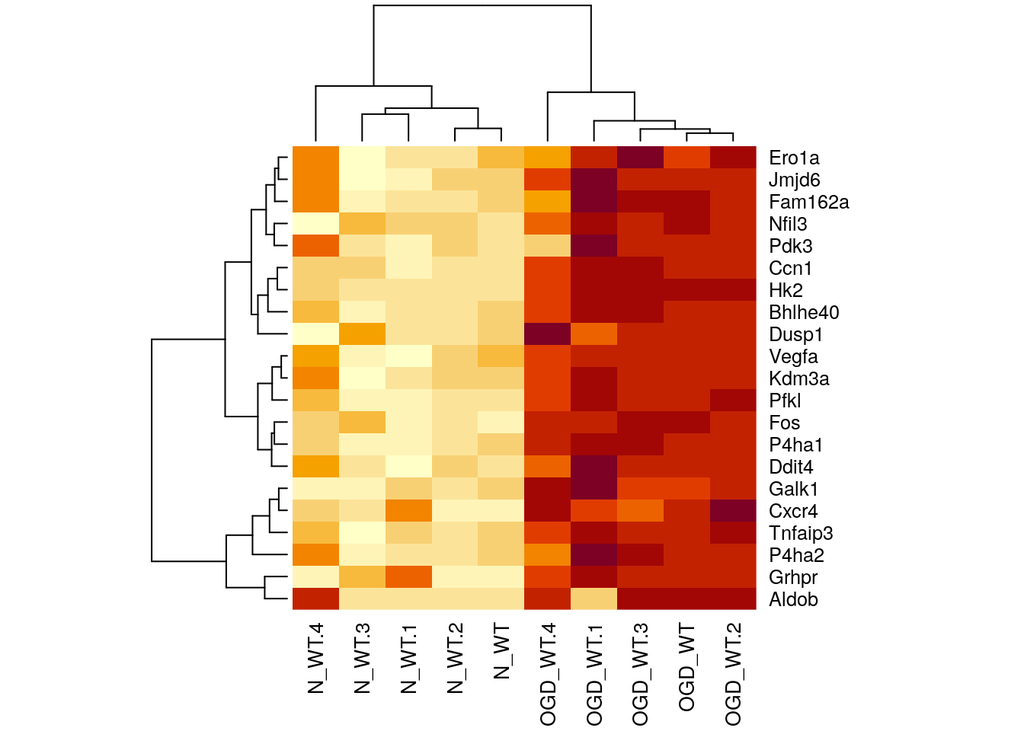

```r
#StellarPath provides access to the normalized counts of the significant molecules behind an enriched pathway and PSN
heatmap(data4pathway$set_counts,cexCol = 1)
```

## PSN Visualization

We extract the PSN of the significant pathway of interest and we visualize it. We now can understand how the patients in study are similar based on the specific pathway information and we can dig in further analysis and conclusions. For example, we can observe which patient is the most important one or is outlier. More details about how to interpret the plot of the PSN are provided in the second vignette.

```
#> Output stored in /media/lg/extHD2/AIVI/REACH/AAA_PACKAGE/StellarPath/vignettes/PSN.pdf
```

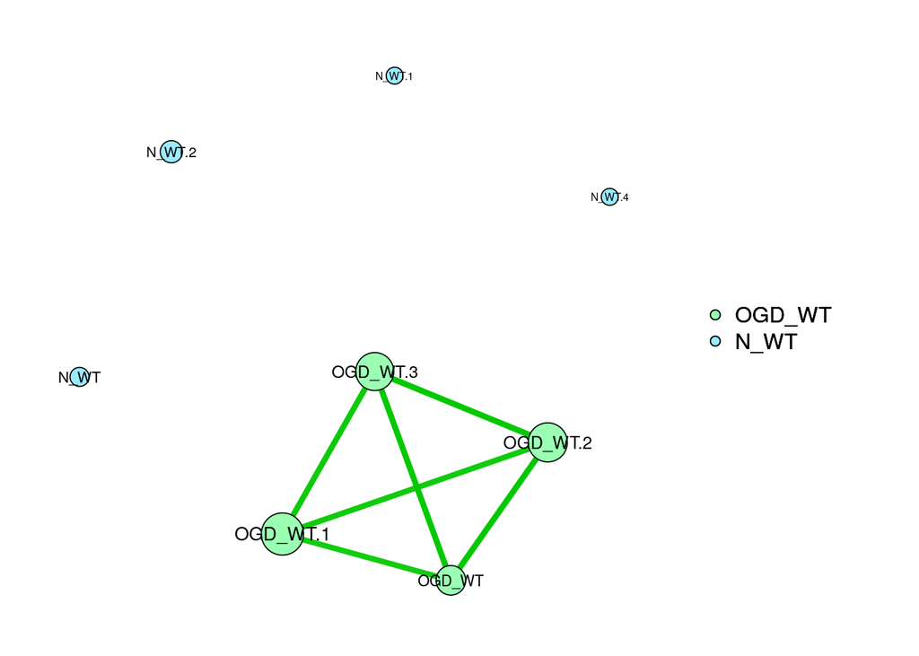

```r
#StellarPath provides access to the PSN associated to the pathway
PSN=data4pathway$PSN
pl_l=plot_PSN(ogd_l$info,PSN,edge_threshold = 0.3,GLratio = 3)
```